# UNIT13B：類別模型、預測機率與商業決策

模型的準確性

第 15 組

2019-05-25 22:10:36

組員：`B044030015 許效軒` `B046060036 王文弘` `B054012011 黃冠綾` `B046060027 姚詠馨` `B046060035 張文瑜` `M074020024 楊長舜`

```r
pacman::p_load(caTools, ggplot2, dplyr)
D = read.csv("data/quality.csv")  # Read in dataset
set.seed(88)
split = sample.split(D$PoorCare, SplitRatio = 0.75)  # split vector
TR = subset(D, split == TRUE)
TS = subset(D, split == FALSE)
glm1 = glm(PoorCare ~ OfficeVisits + Narcotics, TR, family=binomial)
summary(glm1)
```

[output not shown]

### 【A】傳統準確性指標

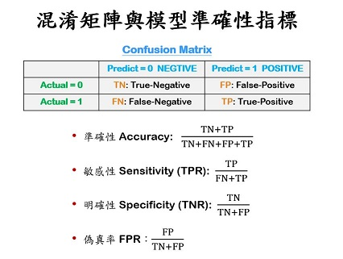

Fig 13.1 - 混淆矩陣與模型準確性指標

##### Training Data

**預測機率 Predicted Probability (Training)**

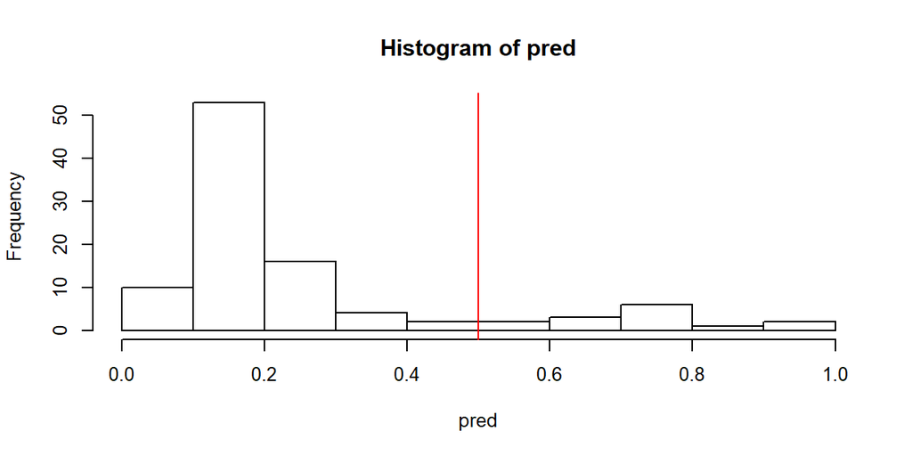

```r
par(cex=0.8)
pred = predict(glm1, type="response")#要算機率一定要寫這個type
hist(pred)
abline(v=0.5, col='red')
```

**混淆矩陣 Confusion Matrix (Training)**

```r
cmx = table(Acture=TR$PoorCare, Predict=pred > 0.5)
# 臨界機率為0.5
cmx
```

```
      Predict
Acture FALSE TRUE
     0    70    4
     1    15   10
```

**模型準確性指標 Accuracy Matrices (Training)**

```r
A2x2 = function(x, k=3) c(
  accuracy = sum(diag(x))/sum(x),
  sensitivity = as.numeric(x[2,2]/rowSums(x)[2]),
  specificity = as.numeric(x[1,1]/rowSums(x)[1])
  ) %>% round(k) #function 小數點三位
A2x2(cmx)
```

```
   accuracy sensitivity specificity
      0.808       0.400       0.946
```

##### Testing Data

**預測機率 Predicted Probability (Testing)**

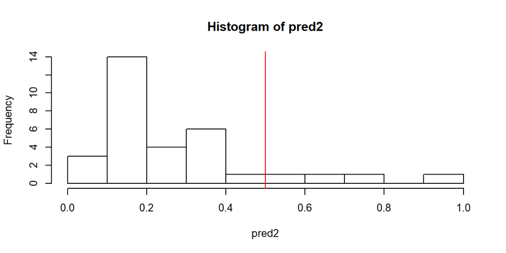

```r
par(cex=0.8)
pred2 = predict(glm1, newdata=TS, type="response") #testing data要放入newdata
hist(pred2, 10)
abline(v=0.5, col='red')
```

**混淆矩陣 Confusion Matrix (Testing)**

```r
cmx2 = table(Acture=TS$PoorCare, Predict=pred2 > 0.5)
cmx2
```

```
      Predict
Acture FALSE TRUE
     0    23    1
     1     5    3
```

**模型準確性指標 Accuracy Matrices (Testing)**

```r
sapply(list(Train=cmx, Test=cmx2), A2x2)
```

```
            Train  Test
accuracy    0.808 0.812
sensitivity 0.400 0.375
specificity 0.946 0.958
```

```r
# 用sapply 對序列中(list)都呼叫後面的function
# 如果training比testing好很多,要考慮過度是配的問題
```

### 【B】預測機率分佈、臨界機率、混淆矩陣

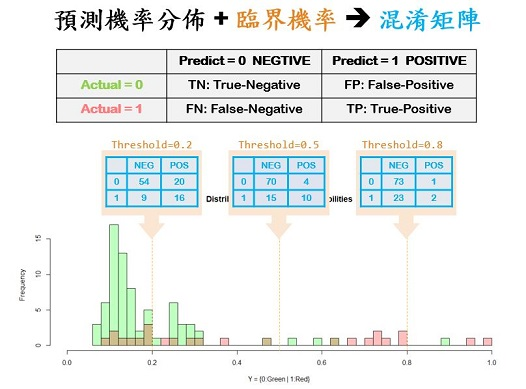

Fig 13.2 - 預測機率分佈、臨界機率、混淆矩陣

**預測機率分佈 (DPP) - Distribution of Predicted Probability (Training)**

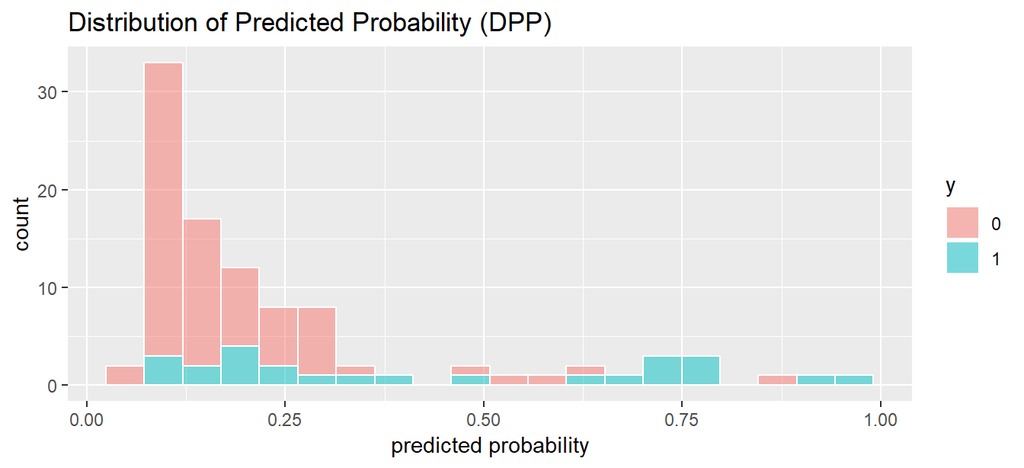

```r
data.frame(y=factor(TR$PoorCare), pred=pred) %>% #要把y作為類別變數,x軸是預測機率
  ggplot(aes(x=pred, fill=y)) +
  geom_histogram(bins=20, col='white', position="stack", alpha=0.5) +
  ggtitle("Distribution of Predicted Probability (DPP)") +
  xlab("predicted probability")
```

```r
# 建議把dpp畫出來再來做臨界機率的劃分
```

### 【C】作業曲線(ROC)與辨識率(AUC)

**ROC - Receiver Operation Curve**

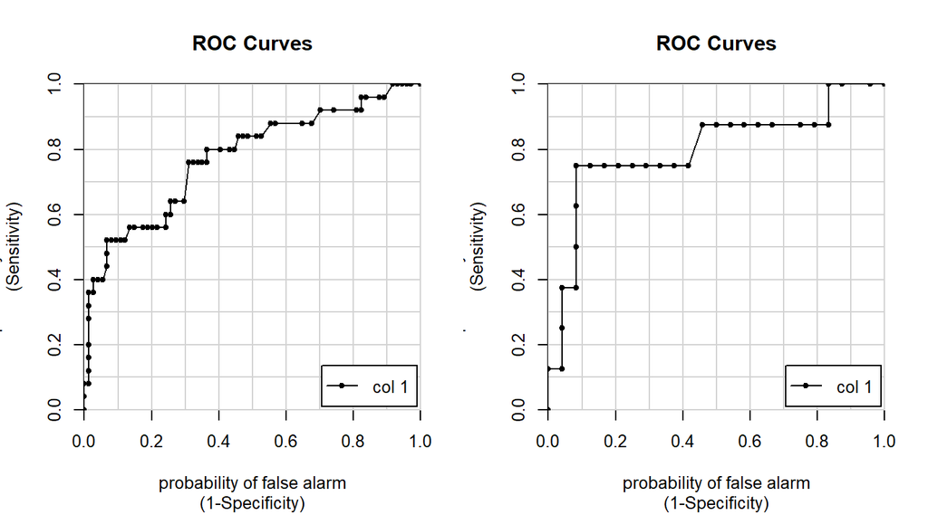

```r
par(mfrow=c(1,2), cex=0.8)
trAUC = colAUC(pred, y=TR$PoorCare, plotROC=T)
tsAUC = colAUC(pred2, y=TS$PoorCare, plotROC=T)
```

```r
# 要畫roc auc 可以用上述函數(需知道預測機率跟目標函數)
```

**AUC - Area Under Curve**

```r
c(trAUC, tsAUC)
```

```
[1] 0.77459 0.79948
```

🗿 練習：  
使用`TR$MemberID`以外的所有欄位，建立一個邏輯式回歸模型來預測`PoorCare`，並：  
【A】 分別畫出`Training`和`Testing`的`DPP`  
【B】 分別畫出`Training`和`Testing`的`ROC`  
【C】 分別算出`Training`和`Testing`的`ACC`、`SENS`和`SPEC`  
【D】 分別算出`Training`和`Testing`的`AUC`  
【E】 跟用兩個預測變數的模型相比，這一個模型有比較準嗎？  
【F】 為什麼它比較準(或比較不準)呢？

# 使用`TR$MemberID`以外的所有欄位，建立一個邏輯式回歸模型來預測`PoorCare`

```r
set.seed(88)
split = sample.split(D$PoorCare, SplitRatio = 0.75)  # split vector
TR = subset(D, split == TRUE)
TS = subset(D, split == FALSE)
glm1 = glm(PoorCare ~ InpatientDays +ERVisits+ OfficeVisits + Narcotics + DaysSinceLastERVisit + Pain + TotalVisits + ProviderCount + MedicalClaims + ClaimLines + StartedOnCombination + AcuteDrugGapSmall, TR, family=binomial)
summary(glm1)
```

```
Call:
glm(formula = PoorCare ~ InpatientDays + ERVisits + OfficeVisits +
    Narcotics + DaysSinceLastERVisit + Pain + TotalVisits + ProviderCount +
    MedicalClaims + ClaimLines + StartedOnCombination + AcuteDrugGapSmall,
    family = binomial, data = TR)

Deviance Residuals:
    Min       1Q   Median       3Q      Max
-1.4950  -0.5389  -0.3037  -0.0612   2.0898

Coefficients: (1 not defined because of singularities)
                         Estimate Std. Error z value Pr(>|z|)
(Intercept)              -1.52721    1.24887   -1.22   0.2214
InpatientDays             0.13978    0.09725    1.44   0.1506
ERVisits                 -0.32645    0.24856   -1.31   0.1891
OfficeVisits              0.09852    0.04687    2.10   0.0355 *
Narcotics                 0.04695    0.04567    1.03   0.3039
DaysSinceLastERVisit     -0.00389    0.00188   -2.06   0.0391 *
Pain                      0.00227    0.01538    0.15   0.8827
TotalVisits                    NA         NA      NA       NA
ProviderCount             0.02847    0.03330    0.85   0.3927
MedicalClaims             0.01568    0.02441    0.64   0.5205
ClaimLines               -0.01055    0.00924   -1.14   0.2535
StartedOnCombinationTRUE  2.34587    1.66703    1.41   0.1594
AcuteDrugGapSmall         0.26808    0.10246    2.62   0.0089 **
---
Signif. codes:  0 '***' 0.001 '**' 0.01 '*' 0.05 '.' 0.1 ' ' 1

(Dispersion parameter for binomial family taken to be 1)

    Null deviance: 111.888  on 98  degrees of freedom
Residual deviance:  72.527  on 87  degrees of freedom
AIC: 96.53

Number of Fisher Scoring iterations: 6
```

# 分別畫出`Training`和`Testing`的`DPP`

**預測機率分佈 (DPP) - Distribution of Predicted Probability (Training)**  
Training Data

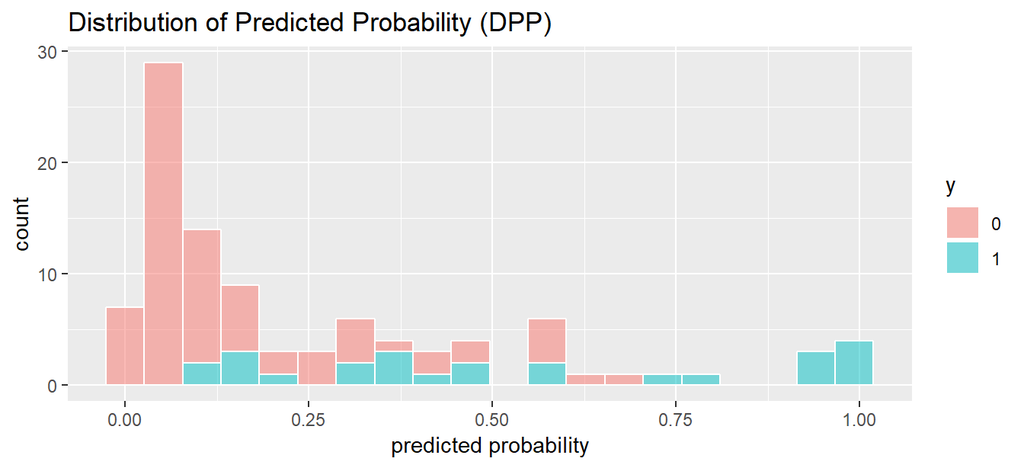

```r
# 預測機率 Predicted Probability (Training)
pred = predict(glm1, type="response")
data.frame(y=factor(TR$PoorCare), pred=pred) %>%
  ggplot(aes(x=pred, fill=y)) +
  geom_histogram(bins=20, col='white', position="stack", alpha=0.5) +
  ggtitle("Distribution of Predicted Probability (DPP)") +
  xlab("predicted probability")
```

Testing Data

```r
# 預測機率 Predicted Probability (Training)
pred2 = predict(glm1, newdata=TS, type="response") #testing data要放入newdata
```

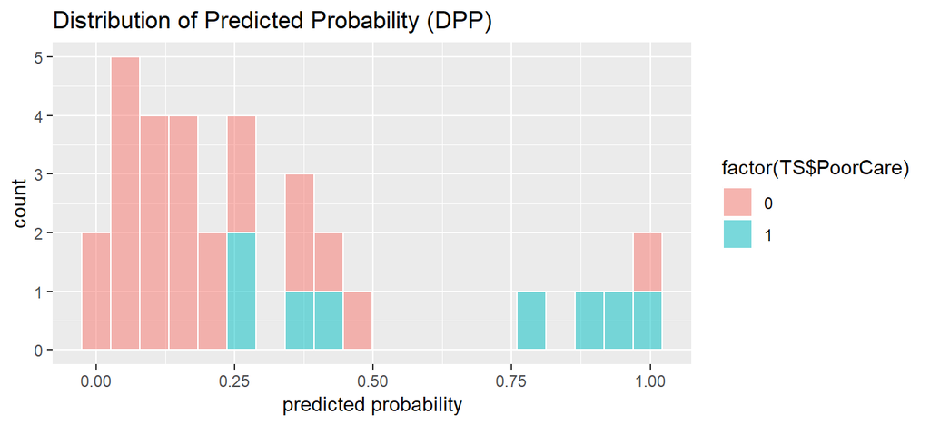

```r
data.frame(y=factor(TS$PoorCare), pred=pred2) %>%
  ggplot(aes(x=pred, fill=factor(TS$PoorCare))) +
  geom_histogram(bins=20, col='white', position="stack", alpha=0.5) +
  ggtitle("Distribution of Predicted Probability (DPP)") +
  xlab("predicted probability")
```

# 分別畫出`Training`和`Testing`的`ROC`

**ROC - Receiver Operation Curve**

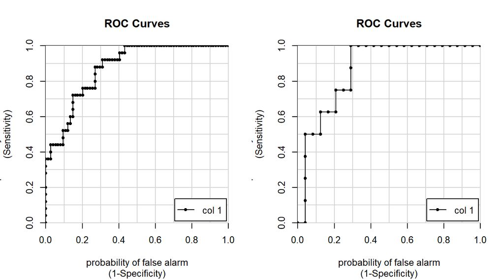

```r
par(mfrow=c(1,2), cex=0.8)
#Training Data
trAUC = colAUC(pred, y=TR$PoorCare, plotROC=T)
#Testing Data
tsAUC = colAUC(pred2, y=TS$PoorCare, plotROC=T)
```

# 分別算出`Training`和`Testing`的`ACC`、`SENS`和`SPEC`

**模型準確性指標 Accuracy Matrices**

- Training data  
  accuracy 0.798  
  sensitivity 0.440  
  specificity 0.919
- Testing Data  
  accuracy 0.844  
  sensitivity 0.500  
  specificity 0.958

```r
# 混淆矩陣 Confusion Matrix (Training)
cmx = table(Acture=TR$PoorCare, Predict=pred > 0.5)
# 臨界機率為0.5
A2x2 = function(x, k=3) c(
  accuracy = sum(diag(x))/sum(x),
  sensitivity = as.numeric(x[2,2]/rowSums(x)[2]),
  specificity = as.numeric(x[1,1]/rowSums(x)[1])
  ) %>% round(k)
cmx2 = table(Acture=TS$PoorCare, Predict=pred2 > 0.5)
sapply(list(Train=cmx, Test=cmx2), A2x2)
```

```
            Train  Test
accuracy    0.798 0.844
sensitivity 0.440 0.500
specificity 0.919 0.958
```

# 分別算出`Training`和`Testing`的`AUC`

**AUC - Area Under Curve**

- Training data  
  Area Under Curve 0.87568
- Testing Data  
  Area Under Curve 0.86458

```r
c(trAUC, tsAUC)
```

```
[1] 0.87568 0.86458
```

# 跟用兩個預測變數的模型相比，這一個模型有比較準嗎？

我們比較準確性指標(acc),發現放入全部變數的預測模型0.844>用兩個預測變數的模型0.812,放入全部變數的模型比較準。  
另外從辨識率來看，多變數模型AUC較大（0.86458＞0.79948），因此模型較能夠正確區辨它們的機率。

# 為什麼它比較準(或比較不準)呢？

因為其訓練所參考的變數較多,所以預測上會更加準確；但考量入多變數也需注意是否有自我相關問題，有可能因此產生自我相關性偏誤或過度配適。